# tugas 7

G14012110834_Dindana Fitriani

2023-10-16

### Library

```r
library("forecast")
```

```r
library("graphics")
library("TTR")
library("TSA")
library(dplyr)
library(forecast)
library(lmtest)
library(orcutt)
library(HoRM)
library(corrplot)
library(dLagM)
library(dynlm)
library(MLmetrics)
library(ggplot2)
library(tsibble)
library(tseries)
library(MASS)
library(aTSA)
```

# Input data

```r
library(rio)
data6 <- import ("https://raw.githubusercontent.com/Dindanafitrianimtd16/Mpdw5/main/Data/data.csv")
data6
```

```
##     Minggu Harga
## 1        1 13700
## 2        2 13700
## 3        3 13700
## 4        4 13650
## 5        5 13700
## 6        6 13700
## 7        7 13700
## 8        8 13700
## 9        9 13700
## 10      10 13700
## 11      11 13700
## 12      12 13700
## 13      13 13750
## 14      14 13700
```

[output cut: 92 more lines]

### Ubah data menjadi time series

```r
data6.ts <- ts(data6$Harga)
```

### Membagi data menjadi data latih (80%) dan data uji (20%) dan jadikan time series

```r
dt6.latih <- data6[1:85,2]
dt6.uji <- data6[86:106,2]
dt6.latih.ts <- ts(dt6.latih, frequency = 12)
dt6.uji.ts <- ts(dt6.uji, frequency = 12)
```

# Eksplorasi data

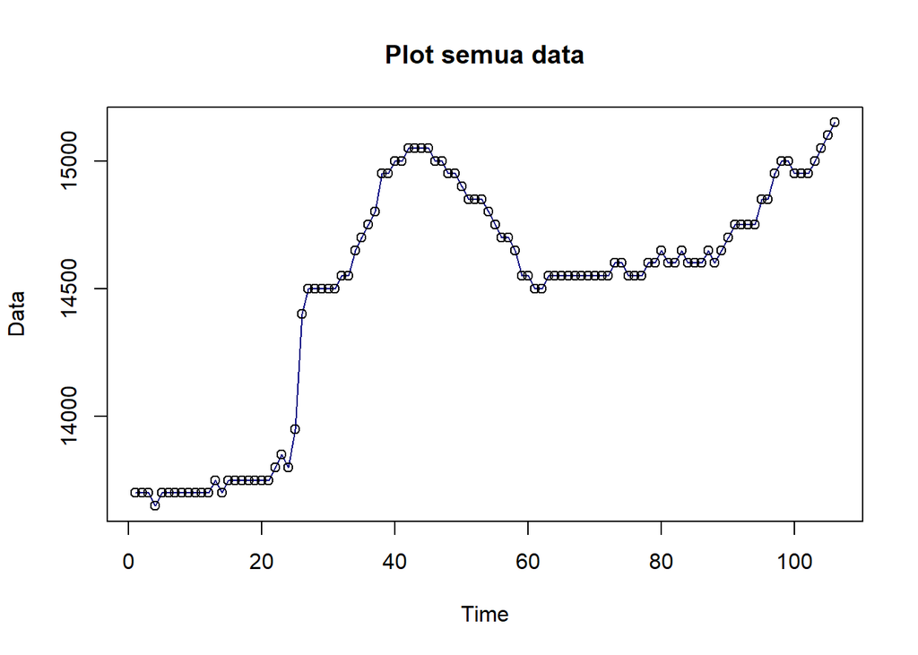

```r
# data full
ts.plot(data6.ts, col="navy",main="Plot semua data", type="o",xlab="Time",ylab="Data")
points(data6.ts)
```

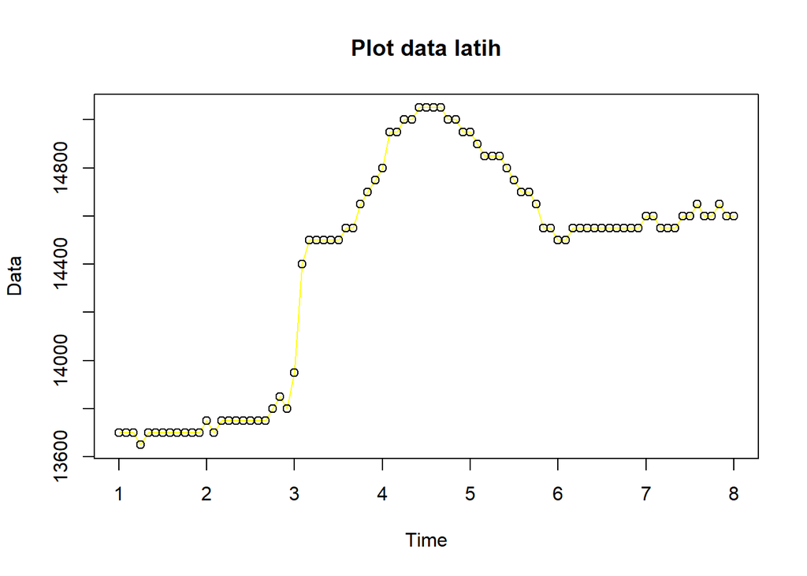

```r
# data latih
ts.plot(dt6.latih.ts, col="yellow",main="Plot data latih", type="o",xlab="Time",ylab="Data")
points(dt6.latih.ts)
```

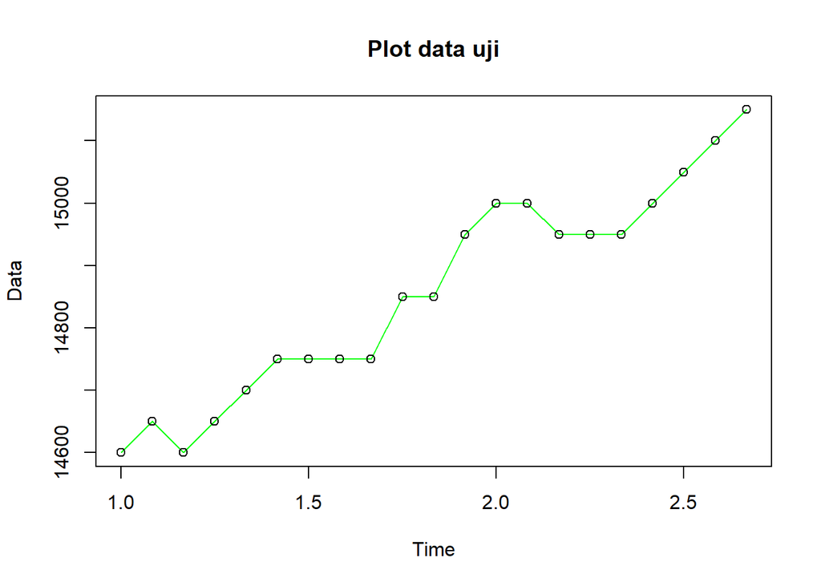

```r
# data uji
ts.plot(dt6.uji.ts, col="green",main="Plot data uji", type="o",xlab="Time",ylab="Data")
points(dt6.uji.ts)
```

dapat dilihat bahwwa data deret waktu pada Hara membentuk pola trend

# CEK Stasioner

### Plot acf

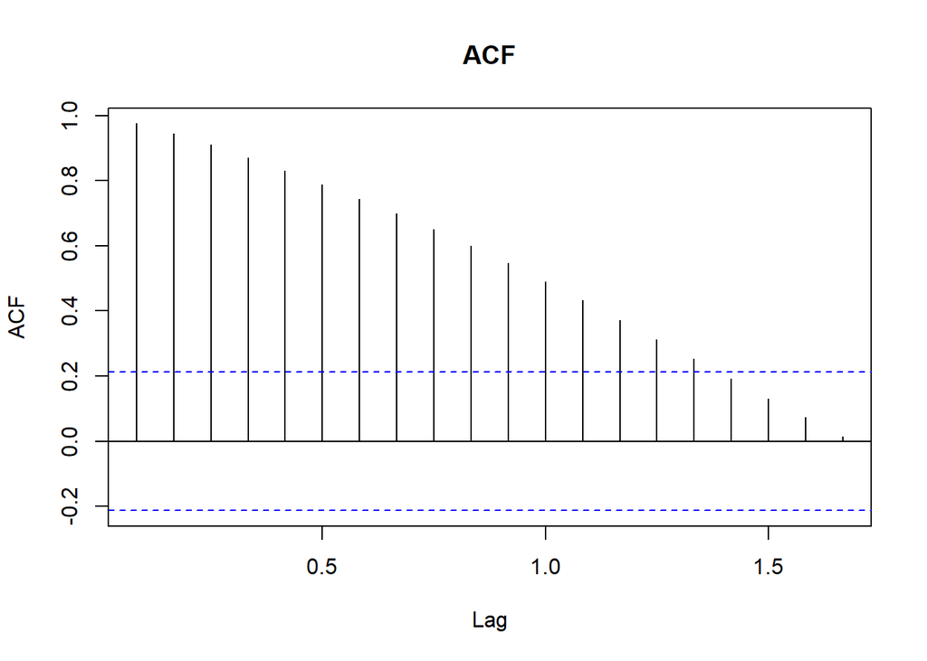

```r
acf(dt6.latih.ts, main="ACF", lag.max=20)
```

Berdasarkan plot ACF, terlihat bahwa plot ACF pada data tersebut cenderung *cut off* slowly menandakan bahwa data tersebut tidak stasioner dalam rataan

### Uji ADF

```r
tseries::adf.test(dt6.latih.ts)
```

```
##
##  Augmented Dickey-Fuller Test
##
## data:  dt6.latih.ts
## Dickey-Fuller = -1.2819, Lag order = 4, p-value = 0.8707
## alternative hypothesis: stationary
```

$H_0$ : Data tidak stasioner dalam rataan

$H_1$ : Data stasioner dalam rataan

Berdasarkan uji ADF tersebut, didapat *p-value* sebesar 0.87 yang lebih besar dari taraf nyata 5% sehingga tak tolak $H_0$ dan menandakan bahwa data tidak stasioner dalam rataan. Hal ini sesuai dengan hasil eksplorasi menggunakan plot time series dan plot ACF.

### Plot Box-Cox

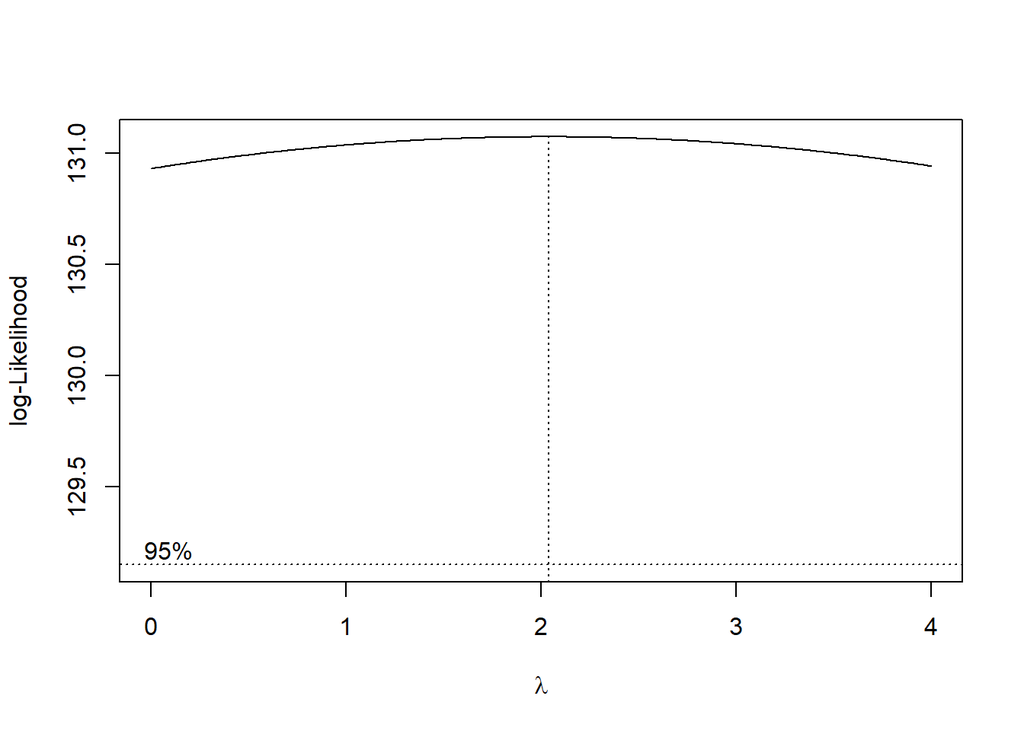

```r
index <- seq(1:85)
bc = boxcox(dt6.latih.ts~index, lambda = seq(0,4,by=0.01))
```

```r
#Nilai Rounded Lambda
lambda <- bc$x[which.max(bc$y)]
lambda
```

```
## [1] 2.04
```

```r
#SK
bc$x[bc$y > max(bc$y) - 1/2 * qchisq(.95,1)]
```

```
##   [1] 0.00 0.01 0.02 0.03 0.04 0.05 0.06 0.07 0.08 0.09 0.10 0.11 0.12 0.13 0.14
##  [16] 0.15 0.16 0.17 0.18 0.19 0.20 0.21 0.22 0.23 0.24 0.25 0.26 0.27 0.28 0.29
##  [31] 0.30 0.31 0.32 0.33 0.34 0.35 0.36 0.37 0.38 0.39 0.40 0.41 0.42 0.43 0.44
##  [46] 0.45 0.46 0.47 0.48 0.49 0.50 0.51 0.52 0.53 0.54 0.55 0.56 0.57 0.58 0.59
##  [61] 0.60 0.61 0.62 0.63 0.64 0.65 0.66 0.67 0.68 0.69 0.70 0.71 0.72 0.73 0.74
##  [76] 0.75 0.76 0.77 0.78 0.79 0.80 0.81 0.82 0.83 0.84 0.85 0.86 0.87 0.88 0.89
##  [91] 0.90 0.91 0.92 0.93 0.94 0.95 0.96 0.97 0.98 0.99 1.00 1.01 1.02 1.03 1.04
## [106] 1.05 1.06 1.07 1.08 1.09 1.10 1.11 1.12 1.13 1.14 1.15 1.16 1.17 1.18 1.19
## [121] 1.20 1.21 1.22 1.23 1.24 1.25 1.26 1.27 1.28 1.29 1.30 1.31 1.32 1.33 1.34
## [136] 1.35 1.36 1.37 1.38 1.39 1.40 1.41 1.42 1.43 1.44 1.45 1.46 1.47 1.48 1.49
## [151] 1.50 1.51 1.52 1.53 1.54 1.55 1.56 1.57 1.58 1.59 1.60 1.61 1.62 1.63 1.64
## [166] 1.65 1.66 1.67 1.68 1.69 1.70 1.71 1.72 1.73 1.74 1.75 1.76 1.77 1.78 1.79
## [181] 1.80 1.81 1.82 1.83 1.84 1.85 1.86 1.87 1.88 1.89 1.90 1.91 1.92 1.93 1.94
## [196] 1.95 1.96 1.97 1.98 1.99 2.00 2.01 2.02 2.03 2.04 2.05 2.06 2.07 2.08 2.09
## [211] 2.10 2.11 2.12 2.13 2.14 2.15 2.16 2.17 2.18 2.19 2.20 2.21 2.22 2.23 2.24
## [226] 2.25 2.26 2.27 2.28 2.29 2.30 2.31 2.32 2.33 2.34 2.35 2.36 2.37 2.38 2.39
## [241] 2.40 2.41 2.42 2.43 2.44 2.45 2.46 2.47 2.48 2.49 2.50 2.51 2.52 2.53 2.54
## [256] 2.55 2.56 2.57 2.58 2.59 2.60 2.61 2.62 2.63 2.64 2.65 2.66 2.67 2.68 2.69
## [271] 2.70 2.71 2.72 2.73 2.74 2.75 2.76 2.77 2.78 2.79 2.80 2.81 2.82 2.83 2.84
## [286] 2.85 2.86 2.87 2.88 2.89 2.90 2.91 2.92 2.93 2.94 2.95 2.96 2.97 2.98 2.99
## [301] 3.00 3.01 3.02 3.03 3.04 3.05 3.06 3.07 3.08 3.09 3.10 3.11 3.12 3.13 3.14
## [316] 3.15 3.16 3.17 3.18 3.19 3.20 3.21 3.22 3.23 3.24 3.25 3.26 3.27 3.28 3.29
## [331] 3.30 3.31 3.32 3.33 3.34 3.35 3.36 3.37 3.38 3.39 3.40 3.41 3.42 3.43 3.44
## [346] 3.45 3.46 3.47 3.48 3.49 3.50 3.51 3.52 3.53 3.54 3.55 3.56 3.57 3.58 3.59
## [361] 3.60 3.61 3.62 3.63 3.64 3.65 3.66 3.67 3.68 3.69 3.70 3.71 3.72 3.73 3.74
## [376] 3.75 3.76 3.77 3.78 3.79 3.80 3.81 3.82 3.83 3.84 3.85 3.86 3.87 3.88 3.89
## [391] 3.90 3.91 3.92 3.93 3.94 3.95 3.96 3.97 3.98 3.99 4.00
```

Gambar di atas menunjukkan nilai *rounded value* ($\lambda$) optimum sebesar **2.04** dan pada selang kepercayaan 95% nilai memiliki batas bawah **0.00** dan batas atas **4.00**. Selang tersebut memuat nilai satu sehingga dapat dikatakan bahwa data bangkitan stasioner dalam ragam.

# Identifikasi model

### Plot ACF dan PACF

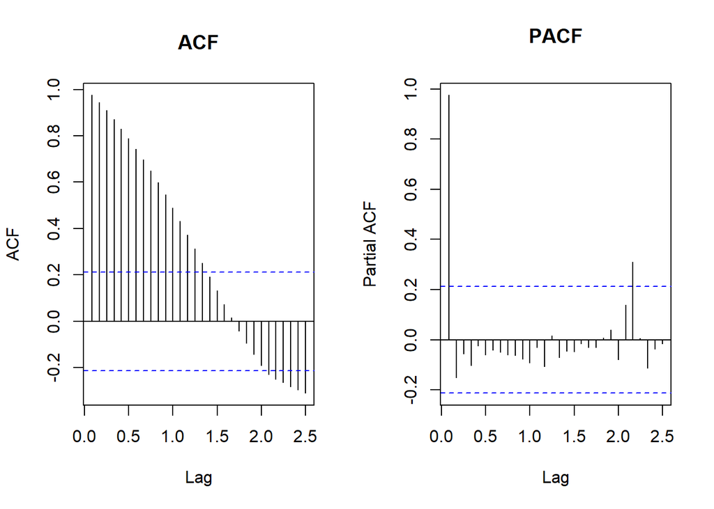

```r
par(mfrow = c(1,2))
acf(dt6.latih.ts, main="ACF", lag.max=30) #ARIMA(0,0,2)
pacf(dt6.latih.ts, main="PACF", lag.max=30) #ARIMA(1,0,0)
```

Berdasarkan plot tersebut, terlihat bahwa plot ACF cenderung taill off slowly

Berdasarkan plot tersebut, terlihat bahwa plot PACF cenderung cuts off pada lag ke 1, sehingga jika plot ACF dianggap tails of, maka model tentatifnya adalah ARIMA(1,0,0).

### Plot EACF

```r
eacf(dt6.latih.ts)
```

```
## AR/MA
##   0 1 2 3 4 5 6 7 8 9 10 11 12 13
## 0 x x x x x x x x x x x  x  x  x
## 1 x o o o o o o o o o o  o  o  o
## 2 o o o o o o o o o o o  o  o  o
## 3 o x o o o o o o o o o  o  o  o
## 4 x o x o o o o o o o o  o  o  o
## 5 o o x o o o o o o o o  o  o  o
## 6 o x o o o o o o o o o  o  o  o
## 7 o x o o o o o o o o o  o  o  o
```

identifikasi model menggunakan plot EACF dilakukan dengan melihat ujung segitiga pada pola segitiga nol. Dalam hal ini model tentatif yang terbentuk adalah ARIMA(1,0,1), dan ARIMA (1,0,2)

sehingga model tentafifnya ialah ARIMA(0,0,1) ARIMA(1,0,0), ARIMA(1,0,1), dan ARIMA (1,0,2)

# Pendugaan Parameter

### ARIMA (0,0,1)

```r
model1=Arima(dt6.latih.ts, order=c(0,0,1),method="ML")
summary(model1) #AIC=1185.73
```

```
## Series: dt6.latih.ts
## ARIMA(0,0,1) with non-zero mean
##
## Coefficients:
##          ma1        mean
##       0.9455  14406.1372
## s.e.  0.0308     51.7276
##
## sigma^2 = 62235:  log likelihood = -589.86
## AIC=1185.73   AICc=1186.02   BIC=1193.06
##
## Training set error measures:
##                    ME     RMSE      MAE         MPE     MAPE      MASE
## Training set 2.427558 246.5173 204.7129 -0.03711673 1.436261 0.6855064
##                   ACF1
## Training set 0.8416978
```

```r
lmtest::coeftest(model1) #signifikan
```

```
##
## z test of coefficients:
##
##             Estimate Std. Error z value  Pr(>|z|)
## ma1       9.4553e-01 3.0847e-02  30.652 < 2.2e-16 ***
## intercept 1.4406e+04 5.1728e+01 278.500 < 2.2e-16 ***
## ---
## Signif. codes:  0 '***' 0.001 '**' 0.01 '*' 0.05 '.' 0.1 ' ' 1
```

### ARIMA (1,0,0)

```r
model2=Arima(dt6.latih.ts, order=c(1,0,0),method="ML")
summary(model2) #AIC=960.43
```

```
## Series: dt6.latih.ts
## ARIMA(1,0,0) with non-zero mean
##
## Coefficients:
##          ar1       mean
##       0.9907  14223.721
## s.e.  0.0098    407.434
##
## sigma^2 = 4305:  log likelihood = -477.22
## AIC=960.43   AICc=960.73   BIC=967.76
##
## Training set error measures:
##                    ME     RMSE      MAE        MPE      MAPE      MASE
## Training set 11.43186 64.83941 33.48993 0.07844804 0.2319905 0.1121452
##                   ACF1
## Training set 0.3183683
```

```r
lmtest::coeftest(model2) #signifikan
```

```
##
## z test of coefficients:
##
##             Estimate Std. Error z value  Pr(>|z|)
## ar1       9.9069e-01 9.8280e-03  100.80 < 2.2e-16 ***
## intercept 1.4224e+04 4.0743e+02   34.91 < 2.2e-16 ***
## ---
## Signif. codes:  0 '***' 0.001 '**' 0.01 '*' 0.05 '.' 0.1 ' ' 1
```

### ARIMA (1,0,1)

```r
model3=Arima(dt6.latih.ts, order=c(1,0,1),method="ML")
summary(model3) #AIC=952.06
```

```
## Series: dt6.latih.ts
## ARIMA(1,0,1) with non-zero mean
##
## Coefficients:
##          ar1     ma1        mean
##       0.9852  0.3424  14251.2926
## s.e.  0.0141  0.0978    379.4816
##
## sigma^2 = 3846:  log likelihood = -472.03
## AIC=952.06   AICc=952.56   BIC=961.83
##
## Training set error measures:
##                    ME     RMSE      MAE        MPE      MAPE      MASE
## Training set 8.850634 60.91195 35.95394 0.06043789 0.2492786 0.1203962
##                      ACF1
## Training set 0.0001229092
```

```r
lmtest::coeftest(model3) #Signifikan
```

```
##
## z test of coefficients:
##
##             Estimate Std. Error z value  Pr(>|z|)
## ar1       9.8525e-01 1.4125e-02 69.7505 < 2.2e-16 ***
## ma1       3.4239e-01 9.7834e-02  3.4997 0.0004658 ***
## intercept 1.4251e+04 3.7948e+02 37.5546 < 2.2e-16 ***
## ---
## Signif. codes:  0 '***' 0.001 '**' 0.01 '*' 0.05 '.' 0.1 ' ' 1
```

### ARIMA (1,0,2)

```r
model4=Arima(dt6.latih.ts, order=c(1,0,2),method="ML")
summary(model4) #AIC=953.84
```

```
## Series: dt6.latih.ts
## ARIMA(1,0,2) with non-zero mean
##
## Coefficients:
##          ar1     ma1     ma2        mean
##       0.9842  0.3583  0.0286  14264.4600
## s.e.  0.0150  0.1057  0.0958    372.3169
##
## sigma^2 = 3883:  log likelihood = -471.92
## AIC=953.84   AICc=954.6   BIC=966.06
##
## Training set error measures:
##                    ME     RMSE      MAE       MPE      MAPE      MASE
## Training set 8.486571 60.83372 35.99542 0.0578751 0.2495883 0.1205351
##                     ACF1
## Training set -0.01650044
```

```r
lmtest::coeftest(model4) #tidak signifikan
```

```
##
## z test of coefficients:
##
##             Estimate Std. Error z value  Pr(>|z|)
## ar1       9.8424e-01 1.5045e-02 65.4204 < 2.2e-16 ***
## ma1       3.5830e-01 1.0569e-01  3.3901 0.0006986 ***
## ma2       2.8611e-02 9.5795e-02  0.2987 0.7651900
## intercept 1.4264e+04 3.7232e+02 38.3127 < 2.2e-16 ***
## ---
## Signif. codes:  0 '***' 0.001 '**' 0.01 '*' 0.05 '.' 0.1 ' ' 1
```

Penduga terbaik ialah aic terkecil dan parameter signifikan yang terdapat di ARIMA(1,0,1)

# analisis sisaan

### Eksplorasi

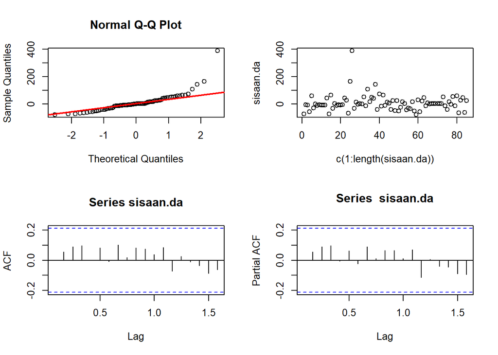

```r
#Eksplorasi
sisaan.da <- model3$residuals
par(mfrow=c(2,2))
qqnorm(sisaan.da)
qqline(sisaan.da, col = "red", lwd = 2)
plot(c(1:length(sisaan.da)),sisaan.da)
acf(sisaan.da)
pacf(sisaan.da)
```

```r
par(mfrow = c(1,1))
```

### Uji Formal

```r
#1) Sisaan Menyebar Normal
ks.test(sisaan.da,"pnorm")
```

```
##
##  Exact one-sample Kolmogorov-Smirnov test
##
## data:  sisaan.da
## D = 0.49431, p-value = 9.992e-16
## alternative hypothesis: two-sided
```

$H_0$ : Sisaan menyebar normal

$H_1$ : Sisaan tidak menyebar normal

```r
#2) Sisaan saling bebas/tidak ada autokorelasi
Box.test(sisaan.da, type = "Ljung")
```

```
##
##  Box-Ljung test
##
## data:  sisaan.da
## X-squared = 1.3299e-06, df = 1, p-value = 0.9991
```

$H_0$ : Sisaan saling bebas

$H_1$ : Sisaan tidak tidak saling bebas

Berdasarkan uji Ljung-Box tersebut, didapat *p-value* sebesar 0.9991 yang lebih besar dari taraf nyata 5% sehingga tak tolak $H_0$ dan menandakan bahwa sisaan saling bebas. Artinya tidak ada autokorelasi

```r
#3) Sisaan homogen
Box.test((sisaan.da)^2, type = "Ljung")
```

```
##
##  Box-Ljung test
##
## data:  (sisaan.da)^2
## X-squared = 1.9431, df = 1, p-value = 0.1633
```

$H_0$ : Ragam sisaan homogen

$H_1$ : Ragam sisaan tidak homogen

Berdasarkan uji Ljung-Box tersebut. didapat *p-value* sebesar0.1633 yang lebih besar dari taraf nyata 5% sehingga tak tolak $H_0$ dan menandakan bahwa ragam sisaan homogen

```r
#4) Nilai tengah sisaan sama dengan nol
t.test(sisaan.da, mu = 0, conf.level = 0.95)  #tak tolak h0 > nilai tengah sisaan sama dengan 0
```

```
##
##  One Sample t-test
##
## data:  sisaan.da
## t = 1.346, df = 84, p-value = 0.1819
## alternative hypothesis: true mean is not equal to 0
## 95 percent confidence interval:
##  -4.225482 21.926750
## sample estimates:
## mean of x
##  8.850634
```

$H_0$ : nilai tengah sisaan sama dengan 0

$H_1$ : nilai tengah sisaan tidak sama dengan 0

Berdasarkan uji-ttersebut, didapat *p-value* sebesar 0.1819 yang lebih besar dari taraf nyata 5% sehingga tak tolak $H_0$ dan menandakan bahwa nilai tengah sisaan sama dengan 0

# Overfitting

### ARIMA(1,0,1)

```r
model5=Arima(dt6.latih.ts, order=c(1,0,1),method="ML")
summary(model5) #AIC=952.06
```

```
## Series: dt6.latih.ts
## ARIMA(1,0,1) with non-zero mean
##
## Coefficients:
##          ar1     ma1        mean
##       0.9852  0.3424  14251.2926
## s.e.  0.0141  0.0978    379.4816
##
## sigma^2 = 3846:  log likelihood = -472.03
## AIC=952.06   AICc=952.56   BIC=961.83
##
## Training set error measures:
##                    ME     RMSE      MAE        MPE      MAPE      MASE
## Training set 8.850634 60.91195 35.95394 0.06043789 0.2492786 0.1203962
##                      ACF1
## Training set 0.0001229092
```

```r
lmtest::coeftest(model5) #Tidak signifikan
```

```
##
## z test of coefficients:
##
##             Estimate Std. Error z value  Pr(>|z|)
## ar1       9.8525e-01 1.4125e-02 69.7505 < 2.2e-16 ***
## ma1       3.4239e-01 9.7834e-02  3.4997 0.0004658 ***
## intercept 1.4251e+04 3.7948e+02 37.5546 < 2.2e-16 ***
## ---
## Signif. codes:  0 '***' 0.001 '**' 0.01 '*' 0.05 '.' 0.1 ' ' 1
```

berdasarkan hasil overfitting yg terbaik tetap model ARIMA(1,0,1)